# R语言练习

huzhibin

2021/9/6

### 赋值

```r
X=0
```

### 循环语句

```r
 for(k in 1:10)
   {X[k]=k^2+1; print(X);}
```

```
## [1] 2
## [1] 2 5
## [1]  2  5 10
## [1]  2  5 10 17
## [1]  2  5 10 17 26
## [1]  2  5 10 17 26 37
## [1]  2  5 10 17 26 37 50
## [1]  2  5 10 17 26 37 50 65
## [1]  2  5 10 17 26 37 50 65 82
##  [1]   2   5  10  17  26  37  50  65  82 101
```

```r
X=0
```

中间没有的数会补上NA

```r
for(k in c(1,2,3,5)){X[k]=k^2+1; print(X);}
```

```
## [1] 2
## [1] 2 5
## [1]  2  5 10
## [1]  2  5 10 NA 26
```

### rbinom(n, size, prob)

生成n个符合B~(size,prob)的数，二项分布，size是试验次数，prob是成功的概率

```r
x=rbinom(10,10,0.3);
print(x);
```

```
##  [1] 3 4 3 3 4 4 5 3 2 2
```

```r
print(sum(x))
```

```
## [1] 33
```

### dbinom(n,size,prob)

给出n点的概率密度

### cbind(a,b)

以列的方式链接(column)

```r
x=0:10;
y=dbinom(x,10,0.5);
print(cbind(x,y))
```

```
##        x            y
##  [1,]  0 0.0009765625
##  [2,]  1 0.0097656250
##  [3,]  2 0.0439453125
##  [4,]  3 0.1171875000
##  [5,]  4 0.2050781250
##  [6,]  5 0.2460937500
##  [7,]  6 0.2050781250
##  [8,]  7 0.1171875000
##  [9,]  8 0.0439453125
## [10,]  9 0.0097656250
## [11,] 10 0.0009765625
```

### rnorm(n,a,b)

生成n个正态随机数，均值为a，标准差为b

```r
 x=rnorm(20,1,0.5); print(x)
```

```
##  [1] 1.9138361 0.5234941 1.5371489 1.1781312 0.6608773 1.3229028 0.6388903
##  [8] 1.7214760 0.9538940 1.5949912 1.0920869 0.6564321 0.2537912 0.8772575
## [15] 1.6136005 0.8546729 1.3517787 1.1833739 0.6989733 0.9637950
```

### rexp(n,a)

指数分布随机数，生成n个参数值$\lambda$为a的随机数，表观来看$\lambda$越小，数值越大。
$$f(x) = λ {e}^{- λ x}$$

```r
y = rexp(20,1); print(y)
```

```
##  [1] 0.1668104 3.0565752 0.4976347 0.6480620 0.1817032 0.7582259 0.3059572
##  [8] 0.0653908 2.5148859 1.1545228 0.8150765 1.3562956 0.8235356 0.8538905
## [15] 0.2190798 1.5140896 0.4406443 0.1205137 1.7852732 0.8551284
```

### 一个维度的绘图

c(x,y)，把x，y连接在了一起

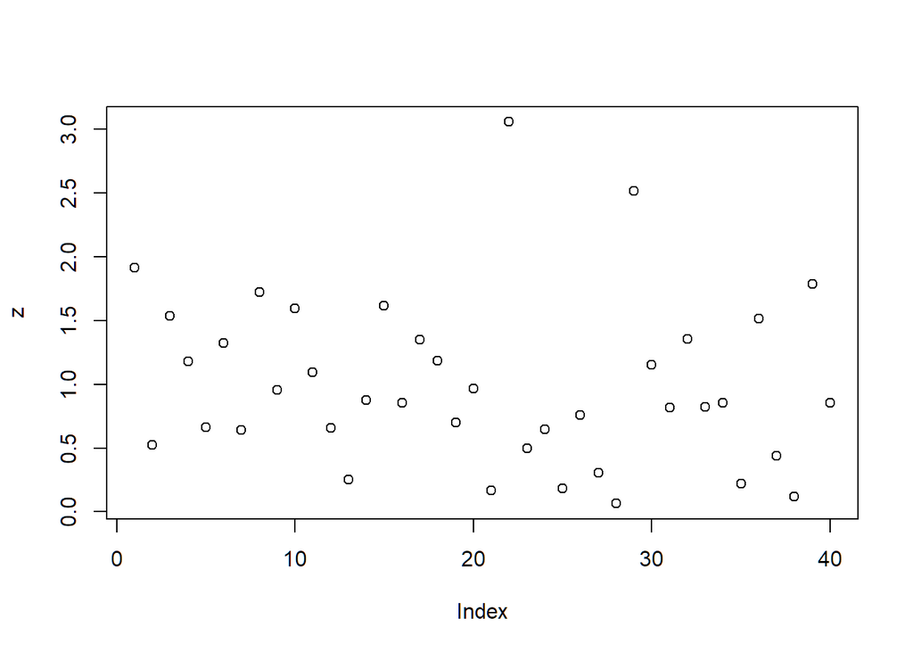

```r
 z = c(x,y);   plot(z)
```

### seq(from=a,to=b,length=n)

从a到b的序列，输出长度为n

### seq(from=a,to=b,by=n)

从a到b的序列，步长为n

```r
seq(1,10,length=5)
```

```
## [1]  1.00  3.25  5.50  7.75 10.00
```

```r
seq(1,10,by=5)
```

```
## [1] 1 6
```

不加by/length默认为by

```r
seq(1,10,5)
```

```
## [1] 1 6
```

```r
Number_Box = 10;
 Bound = seq(from=0,to=1,length=Number_Box);
 SampleX = runif(500);
 Frequence = 0;
 for (k in 1:Number_Box){
     Index=(SampleX>Bound[k])*(SampleX<Bound[k+1]);
     #随机数在而二者中间
     Frequence[k]=sum(Index);}
```

### barplot绘制条形图

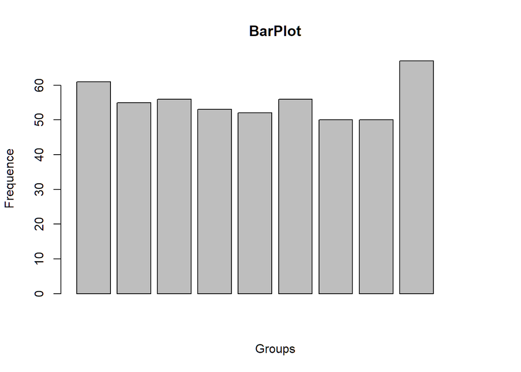

```r
barplot(Frequence,xlab="Groups",ylab="Frequence",main="BarPlot")
```

### hist

hist画条形图，只给一个参数时，默认是频数分布表

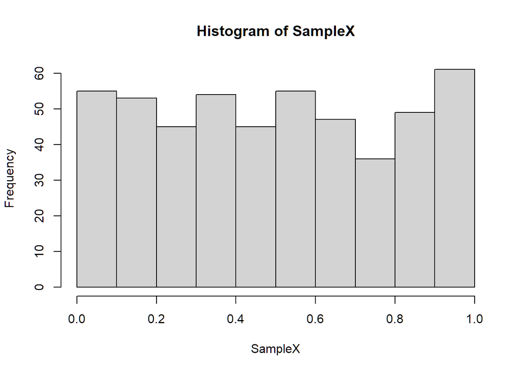

```r
hist(SampleX)
```

### matplot绘图

按照列绘图，pch是点的类型（小于16的整数或者字符），type是图的类型

- ‘p’：仅仅绘制各个散点；
- ‘l’：各个散点构成的连线；
- ‘s’：各个散点构成的阶梯线；
- ‘b’：直线连接各个散点；
- ‘o’ ：直线连接并覆盖各个散点；
- ‘h’ ：绘制点到坐标轴的垂直线；

### apply

apply函数经常用来计算矩阵中行或列的均值、和值的函数

apply(b,1,sum)

第一个参数是指要参与计算的矩阵；

第二个参数是指按行计算还是按列计算，1——表示按行计算，2——按列计算；

第三个参数是指具体的运算参数。

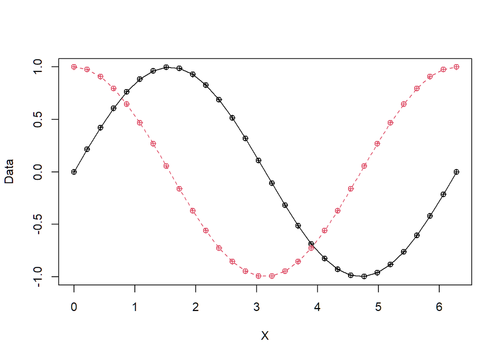

```r
X = seq(0, 2*pi, length = 30);
Y = sin(X);   Z = cos(X);
Data = cbind (Y,Z);
matplot (X, Data, pch = 10, type = 'o');
```

```r
YZ_Min = apply(Data,1,min)
```

### sort排序

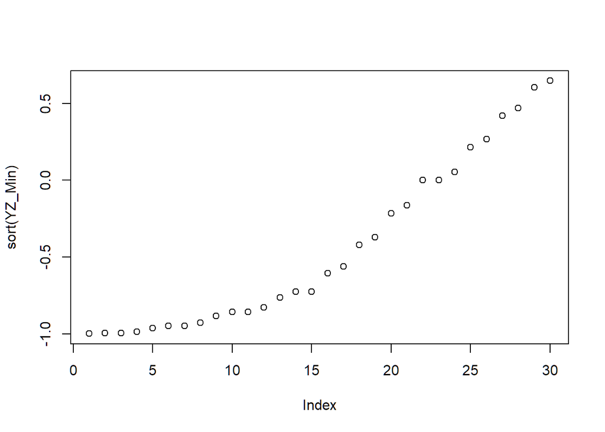

```r
plot(sort(YZ_Min));
```

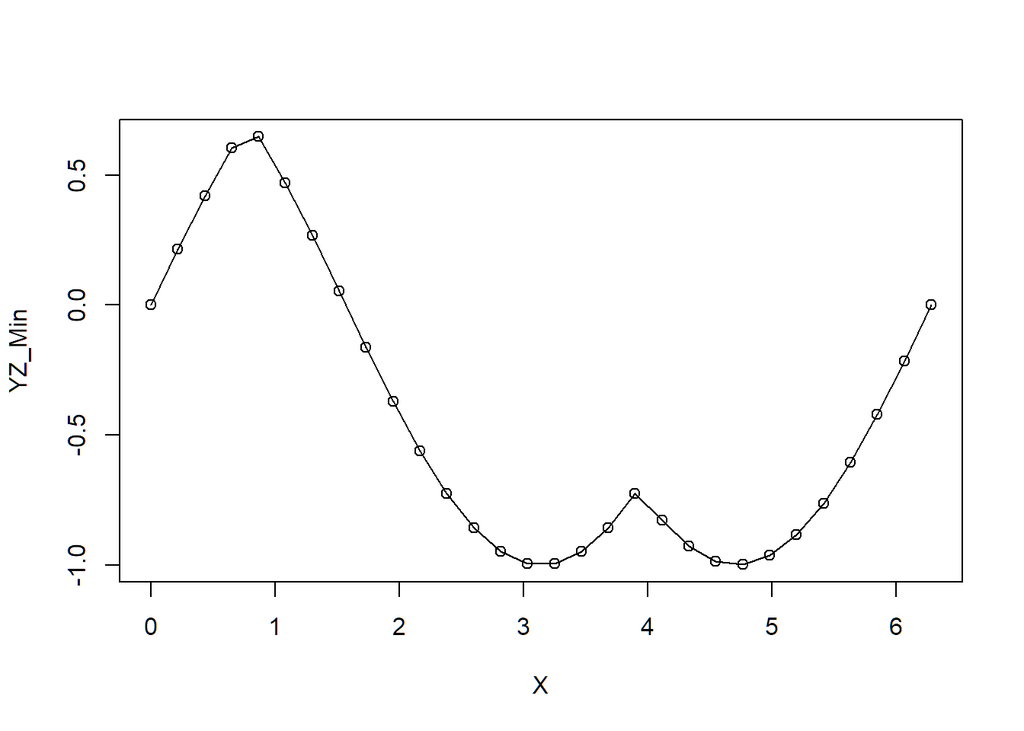

```r
plot(X,YZ_Min);
lines(X,YZ_Min)
```

### combn(x,m)

组合数。 给出所有组合x：包含用于组合的元素的向量 m：选择元素的数量

```r
Sample = combn(1:5,3);
Sample
```

```
##      [,1] [,2] [,3] [,4] [,5] [,6] [,7] [,8] [,9] [,10]
## [1,]    1    1    1    1    1    1    2    2    2     3
## [2,]    2    2    2    3    3    4    3    3    4     4
## [3,]    3    4    5    4    5    5    4    5    5     5
```

### colSums

按列求和，可以直接求和布尔值

```r
Number_Waster = colSums(Sample <= 2);
Number_Waster
```

```
##  [1] 2 2 2 1 1 1 1 1 1 0
```

```r
Selection = (Number_Waster == 1);
Selection
```

```
##  [1] FALSE FALSE FALSE  TRUE  TRUE  TRUE  TRUE  TRUE  TRUE FALSE
```

```r
Probability = sum(Selection)/choose(5,3);
Probability
```

```
## [1] 0.6
```

### choose

choose(n,k)，给出$C^k_n$的值

```r
choose(5,2)
```

```
## [1] 10
```

### sample抽样

sample(x,size,replace)

replace=T，有放回，默认无放回 ### 省略参数必须位置对应，带参数可以颠倒位置

```r
sample(size=20,replace=T,x=1:9)
```

```
##  [1] 8 6 7 3 8 6 8 5 8 5 7 3 2 2 6 4 7 8 7 4
```

```r
sample(1:9,20,replace=T)
```

```
##  [1] 1 9 1 9 7 8 5 8 1 6 4 8 4 4 5 3 9 8 3 2
```

### matrix生成矩阵

matrix(x,nrow=2,ncol=3)

```r
matrix(1:10,2,5)
```

```
##      [,1] [,2] [,3] [,4] [,5]
## [1,]    1    3    5    7    9
## [2,]    2    4    6    8   10
```

```r
SampleX = 1:5 <= 2;
Number_Repeat = 100;
Sample_Random = sample(SampleX,Number_Repeat*3,replace=TRUE);
SampleY = matrix(Sample_Random,nrow=Number_Repeat,ncol=3);
for(k in 1:Number_Repeat){SampleY[k,] = sample(SampleX,3)};
Number_Waster = rowSums(SampleY);
Selection = (Number_Waster == 1);
Frequency = sum(Selection)/Number_Repeat;
print(Frequency-Probability)
```

```
## [1] -0.08
```

### sd标准差

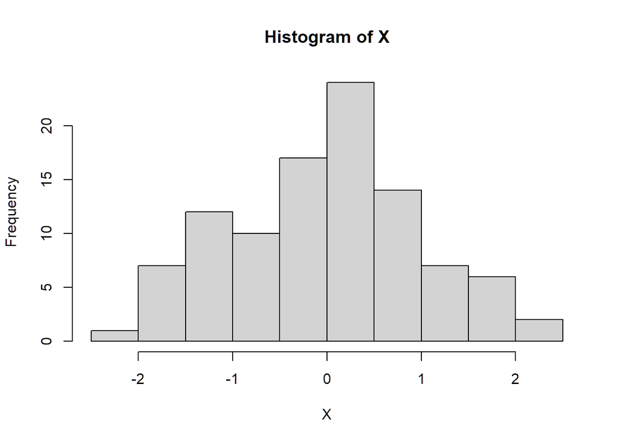

```r
X = rnorm(100,0,1);  hist(X);
```

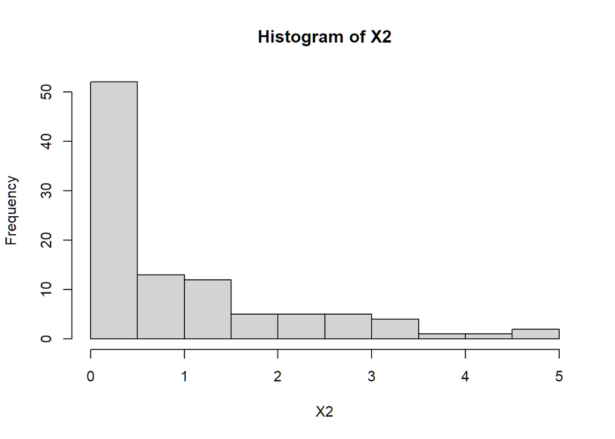

```r
X2 = X^2;  hist(X2);
```

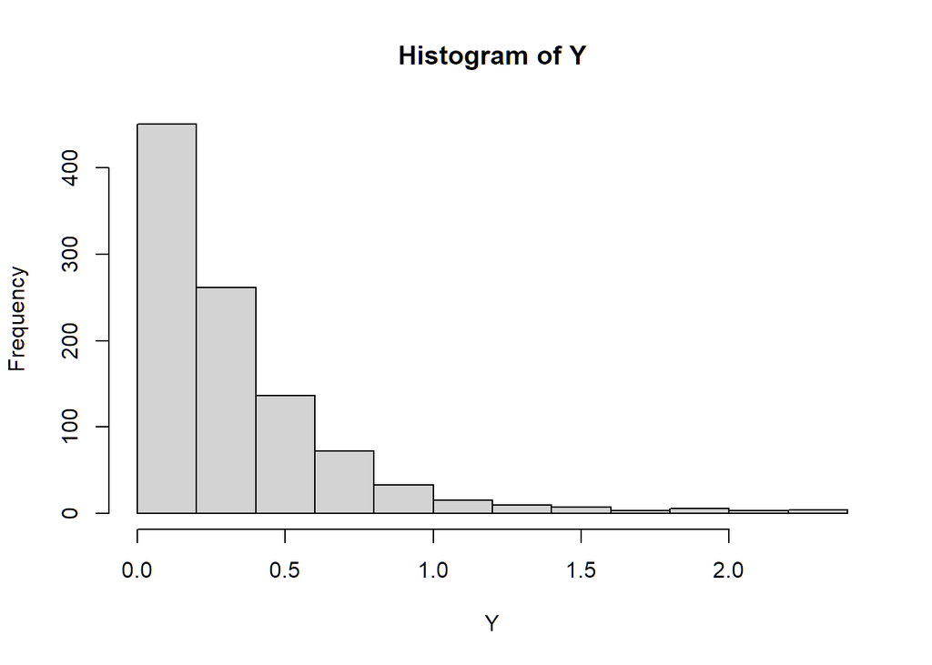

```r
E_X2 = mean(X2); D_X2 = sd(X2);
Y = rexp(1000,3);  hist(Y);
```

```r
E_X2 = mean(X2); D_X2 = sd(X2)
```

### lines连线

hist加入freq=F可以把纵轴变成密度。

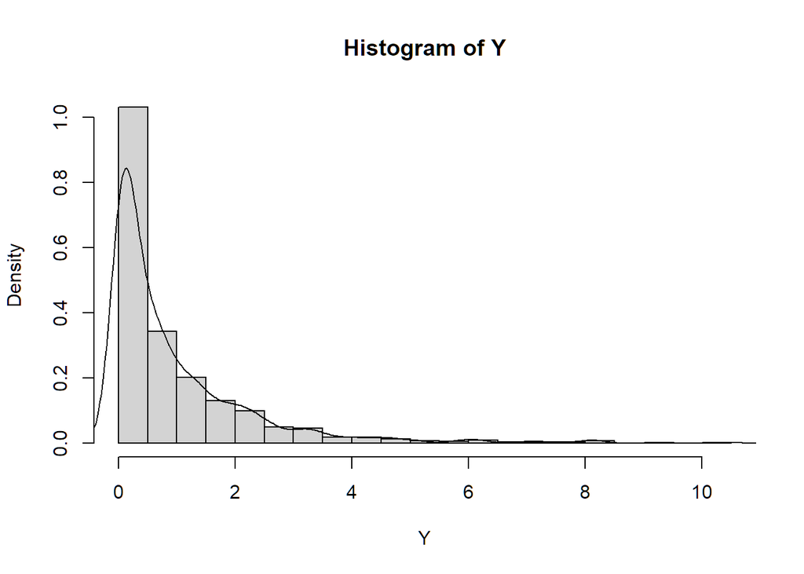

```r
X = rnorm(1000);
Y = X^2;
hist(Y,20,freq = F);
lines(density(Y))
```

### boxplot

boxplot画箱线图

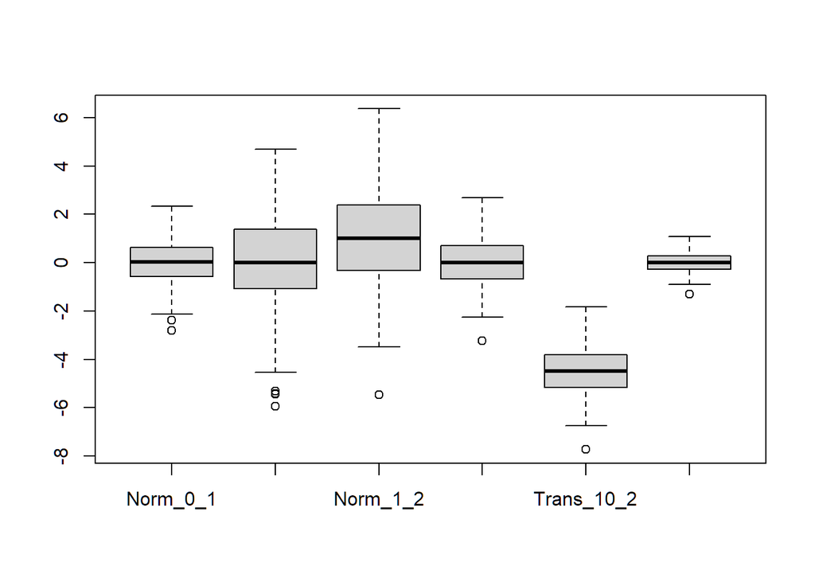

```r
Norm_0_1 = rnorm(200,0,1);
Norm_0_2 = rnorm(200,0,2);
Norm_1_2 = rnorm(200,1,2);
Trans_1_2 = (Norm_1_2-1)/2;
Trans_10_2 = (Norm_1_2-10)/2;
Trans_1_5 = (Norm_1_2-1)/5;
Data= cbind(Norm_0_1,Norm_0_2,Norm_1_2,Trans_1_2,Trans_10_2,Trans_1_5);
boxplot(Data)
```

**自定义函数不明白???????**

```r
Statistic_T <- function(Number_Sample){
    X = rnorm(Number_Sample);
    S_T = (X-mean(X))/sd(X);
    return(S_T)}
Number_Sample = 100;
Number_Repeat = 200;
Vector_T = as.numeric(vector(length=Number_Repeat))
for (k in 1:Number_Repeat){
    Vector_T[k]= Statistic_T(Number_Sample)};
```

[output not shown]

[output cut: 544 more lines]

[output not shown]

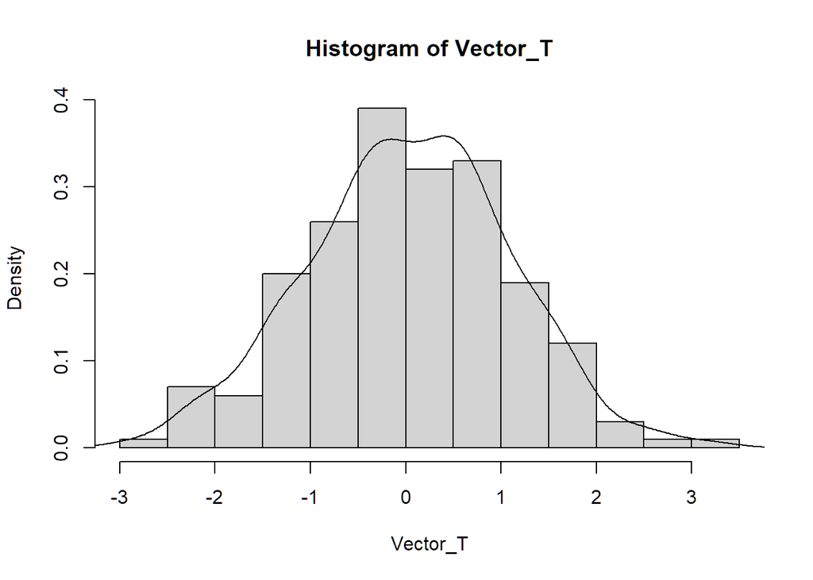

```r
hist(Vector_T,freq=F);
lines(density(Vector_T))
```

### vector

vector(length=n)生成长度为n的向量，内容全为FALSE

```r
vector(length=20)
```

```
##  [1] FALSE FALSE FALSE FALSE FALSE FALSE FALSE FALSE FALSE FALSE FALSE FALSE
## [13] FALSE FALSE FALSE FALSE FALSE FALSE FALSE FALSE
```

### as.numeric

转化为数字

```r
as.numeric(vector(length=20))
```

```
##  [1] 0 0 0 0 0 0 0 0 0 0 0 0 0 0 0 0 0 0 0 0
```

```r
Statistic_T <- function(Number_Sample){
    X = rnorm(Number_Sample);
    S_T = (X-mean(X))/sd(X);
    return(S_T)}
Statistic_T(3)
```

```
## [1]  1.1431844 -0.7124719 -0.4307125
```